# Data Analytics 2025

Guillem Plademunt, Bernat Garcia, Javier Ezquerro and Marc Soriano

# 1 Descriptive Analytics

Before we start with any analysis, we need to understand the data that is available and the general distribution of the variables, in terms of central tendency and dispersion. Also, visualisation helps understand the data.

```r
#read the file
DS <- read.csv("gaming_data.csv")
colnames(DS)
```

```
## [1] "player_id"   "group"       "playtime"    "sessions"    "levels"
## [6] "friends"     "skill_score" "spending"    "user_type"
```

## 1.1 Descriptive metrics

We created a function to calculate the descriptive metrics (playtime, sessions, levels completed, and spending) for all users, Premium users, and Freemium users. Then, we generated the Premium and Freemium datasets, applied the function to each segment, and finally used kableExtra to display the results in clean, formatted tables.

```r
# 1 Function to compute descriptive metrics

describe_segment <- function(df, segment_name)
{
  data.frame(
    Segment = segment_name,
    Variable = c("playtime", "sessions", "levels", "spending"),
    Average = c(mean(df$playtime),
                mean(df$sessions),
                mean(df$levels),
                mean(df$spending)),
    StandardDeviation = c(sd(df$playtime),
                          sd(df$sessions),
                          sd(df$levels),
                          sd(df$spending))
  )
}

# 2 Premium and Freemium datasets

DS_Premium  <- DS[DS$user_type == "Premium", ]
DS_Freemium <- DS[DS$user_type == "Freemium", ]

# 3 Generate all tables

global_table   <- describe_segment(DS,          "All users")
premium_table  <- describe_segment(DS_Premium,  "Premium")
freemium_table <- describe_segment(DS_Freemium, "Freemium")

# ---- GLOBAL TABLE ----
global_table %>%
  kable(format = "html", digits = 2,
        caption = "Global - Descriptive Metrics") %>%
  kable_styling(bootstrap_options = c("striped", "hover", "condensed")) %>%
  column_spec(1, bold = TRUE) %>%
  column_spec(2, bold = TRUE) %>%
  column_spec(3, color = "blue") %>%
  column_spec(4, color = "darkred")
```

Global - Descriptive Metrics

| Segment | Variable | Average | StandardDeviation |
| --- | --- | --- | --- |
| All users | playtime | 60.05 | 10.96 |
| All users | sessions | 8.93 | 3.15 |
| All users | levels | 4.49 | 2.40 |
| All users | spending | 11.99 | 19.85 |

```r
# ---- PREMIUM TABLE ----
premium_table %>%
  kable(format = "html", digits = 2,
        caption = "Premium Users - Descriptive Metrics") %>%
  kable_styling(bootstrap_options = c("striped", "hover", "condensed")) %>%
  column_spec(1, bold = TRUE) %>%
  column_spec(2, bold = TRUE) %>%
  column_spec(3, color = "blue") %>%
  column_spec(4, color = "darkred")
```

Premium Users - Descriptive Metrics

| Segment | Variable | Average | StandardDeviation |
| --- | --- | --- | --- |
| Premium | playtime | 65.57 | 11.13 |
| Premium | sessions | 9.33 | 3.41 |
| Premium | levels | 4.75 | 2.55 |
| Premium | spending | 25.84 | 23.77 |

```r
# ---- FREEMIUM TABLE ----
freemium_table %>%
  kable(format = "html", digits = 2,
        caption = "Freemium Users - Descriptive Metrics") %>%
  kable_styling(bootstrap_options = c("striped", "hover", "condensed")) %>%
  column_spec(1, bold = TRUE) %>%
  column_spec(2, bold = TRUE) %>%
  column_spec(3, color = "blue") %>%
  column_spec(4, color = "darkred")
```

Freemium Users - Descriptive Metrics

| Segment | Variable | Average | StandardDeviation |
| --- | --- | --- | --- |
| Freemium | playtime | 59.84 | 10.90 |
| Freemium | sessions | 8.92 | 3.14 |
| Freemium | levels | 4.48 | 2.39 |
| Freemium | spending | 11.47 | 19.50 |

## 1.2 Game Performance Metrics

Using the data available in the dataset, we computed the following game performance metrics: ARPU, ARPPU, conversion rate and average engagement index.

```r
# ARPU
ARPU <- mean(DS$spending)

# ARPPU
paying_users <- DS[DS$spending > 0,]
ARPPU <- mean(paying_users$spending)

# Conversion Rate
conversion_rate <- nrow(paying_users) / nrow(DS)

# Engagement index per player
DS$engagement_index <- DS$playtime * DS$sessions

# Average Engagement Index
avg_engagement <- mean(DS$engagement_index)

# Results
metrics <- data.frame(
  Metric = c("**ARPU**", "**ARPPU**", "**Conversion Rate**", "**Average Engagement Index**"),
  Value = c(ARPU, ARPPU, conversion_rate, avg_engagement)
)

metrics %>%
  mutate(Value = format(Value, digits = 2, nsmall = 2)) %>%
  kable(caption = "Game Performance Metrics", escape = FALSE) %>%
  kable_styling(full_width = TRUE, bootstrap_options = c("striped", "hover"))
```

Game Performance Metrics

| Metric | Value |
| --- | --- |
| **ARPU** | 11.99 |
| **ARPPU** | 43.14 |
| **Conversion Rate** | 0.28 |
| **Average Engagement Index** | 541.82 |

# 2 Visuals

#1  
This code creates a pie chart showing the percentages of Premium vs Freemium users. It counts the number of users of each type and converts it to percentages. The chart displays proportional sections with the percentage labels inside each slice. It allows a quick visual comparison of the distribution of user types in the dataset.

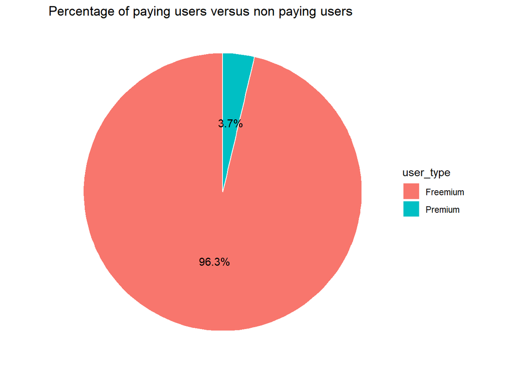

```r
#1
# Percentage of paying users versus non paying users.
percent_summary <- DS %>%
  group_by(user_type) %>%
  summarise(count = n()) %>%
  mutate(percent = count / sum(count) * 100)

ggplot(percent_summary, aes(x = "", y = percent, fill = user_type)) +
  geom_col(width = 1, color = "white") +
  coord_polar(theta = "y") +
  geom_text(aes(label = paste0(round(percent,1), "%")),
            position = position_stack(vjust = 0.5)) +
  labs(title = "Percentage of paying users versus non paying users") +
  theme_void()
```

#2  
This code creates a boxplot comparing playtime between group A and group B. It first calculates an engagement index as playtime * sessions, although the plot shows only playtime. Each box shows the median, quartiles, and outliers for each group. It allows visual comparison of how playtime differs between the two groups.

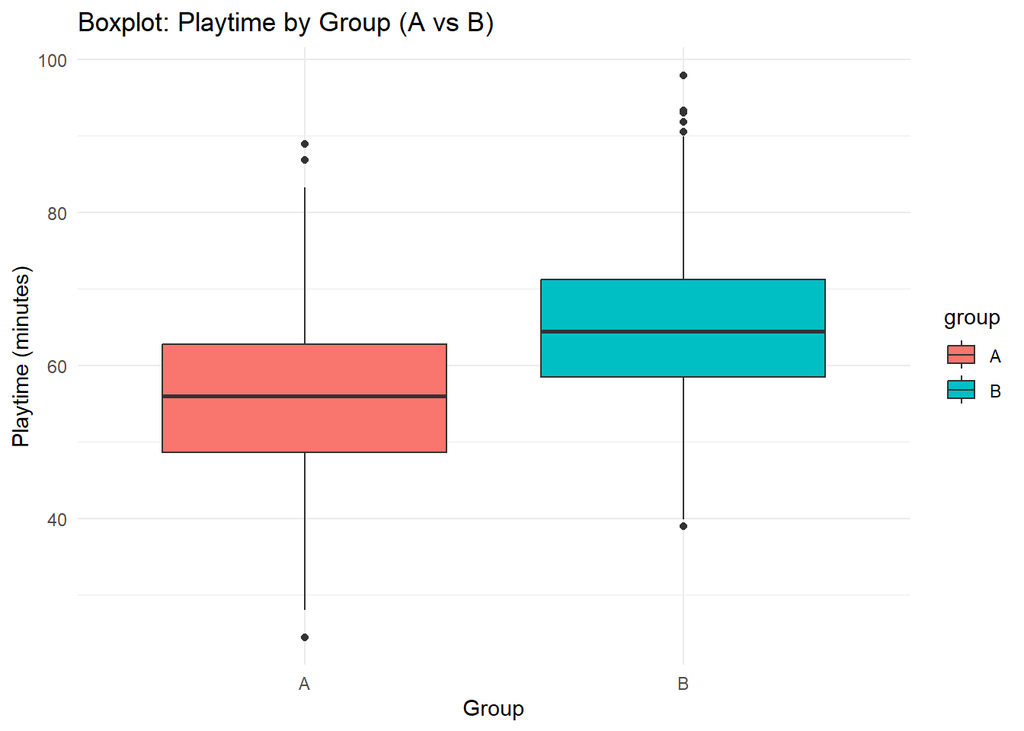

```r
#2
# Boxplot comparing playtime and engagement of group A vs. group B.
DS <- DS %>%
  mutate(engagement = playtime * sessions)

# Boxplot de playtime per grup
ggplot(DS, aes(x = group, y = playtime, fill = group)) +
  geom_boxplot() +
  labs(title = "Boxplot: Playtime by Group (A vs B)",
       x = "Group",
       y = "Playtime (minutes)") +
  theme_minimal()
```

#3  
This code creates a line plot showing the relationship between sessions and levels completed. Each group (A and B) is represented with a different color. Points show actual values, and lines connect them to highlight trends. It allows visual comparison of how levels completed change with sessions for each group.

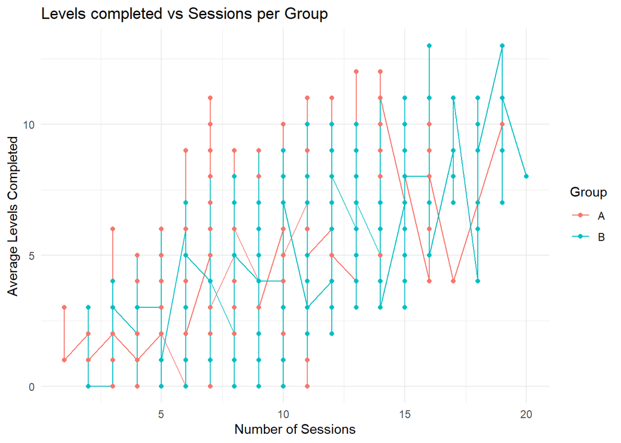

```r
#3
# Line plot: Levels completed vs Sessions per Group
ggplot(DS, aes(x = sessions, y = levels, color = group)) +
  geom_line() +
  geom_point() +
  labs(title = "Levels completed vs Sessions per Group",
       x = "Number of Sessions",
       y = "Average Levels Completed",
       color = "Group") +
  theme_minimal()
```

# 3 AB testing

## 3.1 Test 1

The designers aim to investigate whether the players will have a playtime greater than 60 minutes in average. Can you answer this question using the current sample? Use a confidence level of 95%.

### 3.1.1 Research question

Is the average playing time of the players significantly higher than 60 minutes?

### 3.1.2 Hypotheses

H₀: μ ≤ 60

H₁: μ > 60

### 3.1.3 Type of test

One sample, one-tailed test

### 3.1.4 Computations

```r
# Sample size
n <- length(DS$playtime)

# Sample mean
x_bar <- mean(DS$playtime)

# Sample standard deviation
s <- sd(DS$playtime)

#Mean according to H₀
mu0 <- 60

# Observed statistic
t_stat <- (x_bar - mu0) / (s / sqrt(n))
t_stat
```

```
## [1] 0.1865369
```

```r
# P-value
p_value <- 1 - pt(t_stat, df = n-1)
p_value
```

```
## [1] 0.4260245
```

```r
# Significance level
alpha <- 0.05

# Decision
if(p_value < alpha){
  print("Reject H0: the mean is significantly greater than 60")
} else {
  print("Fail to reject H0: there is not enough evidence that the mean is > 60")
}
```

```
## [1] "Fail to reject H0: there is not enough evidence that the mean is > 60"
```

### 3.1.5 Interpretation

The average playtime of the players in the current sample is slightly above 60 minutes (x = 60.05). However, the observed difference from the hypothesized value of 60 minutes is not statistically significant at the 95% confidence level (p-value > 0.05).

Therefore, we fail to reject the null hypothesis. This means there is not enough evidence to conclude that the average playtime of players is significantly greater than 60 minutes.

## 3.2 Test 2

The indie studio tested two different versions of the game on the current users. The users labeled as A downloaded the standard version of the game, while users in group B downloaded a new version with an improved reward system. The designers believed that the new reward system will produce higher playtime among the users. Can you search in the data whether there is evidence to do such claim with 95% confidence level?

### 3.2.1 Research question

Does the new version of the game with an improved reward system (Group B) result in higher average playtime compared to the standard version (Group A)?

### 3.2.2 Hypotheses

Null hypothesis: H0: μB ≤ μA  
Alternative hypothesis: H1: μB > μA

### 3.2.3 Type of test

Two independent samples, one-tailed test, upper tail.

### 3.2.4 Computations

```r
# Sample sizes
n_A <- sum(DS$group == "A")
n_B <- sum(DS$group == "B")

# Sample means
mean_A <- mean(DS$playtime[DS$group == "A"])
mean_B <- mean(DS$playtime[DS$group == "B"])

# Sample variances
var_A <- var(DS$playtime[DS$group == "A"])
var_B <- var(DS$playtime[DS$group == "B"])

# Observed value
t_obs <- (mean_B - mean_A) / sqrt(var_B/n_B + var_A/n_A)

# Degrees of freedom
df_num <- (var_B/n_B + var_A/n_A)^2
df_den <- ( (var_B/n_B)^2 / (n_B - 1) ) + ( (var_A/n_A)^2 / (n_A - 1) )
df <- df_num / df_den

# Critical t-value (upper tail)
t_crit <- qt(0.95, df)

# p-value
p_val <- 1 - pt(t_obs, df)
```

Sample sizes: nA = 767, nB = 733

Means: XA = 55.50, XB = 64.81

Variances:s^2A = 104.12, S^2B = 92.766

Observed t-value: tobs = 18.17

Critical t-value (upper tail, 95%): tcrit = 1.6458

p-value: p ≈ 0

Degrees of freedom (df) ~ 1497.77

tobs = 18.17 vs tcrit = 1.65  
Since,  
tobs > tcrit.  
We reject the null hypothesis.

### 3.2.5 Interpretation

With 95% confidence, the new version of the game with the improved reward system (Group B) results in higher average playtime than the standard version (Group A).

On average, players in Group B played 64.81 minutes per session, while players in Group A played 55.50 minutes.

The difference is significant, and the evidence strongly supports the designers’ claim.

# 4 Regression analysis

In this section, we’ll build a regression model to assess whether the player’s spending amount can be predicted based on the other variables.

## 4.1 Regression model with numerical variables

```r
# variables: playtime sessions, levels, friends and skill_score.

DS_Predict_Regression <- DS[, c("sessions", "levels", "friends", "skill_score", "playtime", "spending")]
model <- lm( spending ~ ., DS_Predict_Regression)
summary(model)
```

```
##
## Call:
## lm(formula = spending ~ ., data = DS_Predict_Regression)
##
## Residuals:
##    Min     1Q Median     3Q    Max
## -14.65 -12.42 -11.42  20.52  62.93
##
## Coefficients:
##             Estimate Std. Error t value Pr(>|t|)
## (Intercept)  8.50024    3.95539   2.149   0.0318 *
## sessions    -0.27283    0.20815  -1.311   0.1901
## levels       0.20691    0.27242   0.760   0.4477
## friends      0.14609    0.23216   0.629   0.5293
## skill_score  0.03449    0.02949   1.169   0.2424
## playtime     0.03070    0.04745   0.647   0.5177
## ---
## Signif. codes:  0 '***' 0.001 '**' 0.01 '*' 0.05 '.' 0.1 ' ' 1
##
## Residual standard error: 19.86 on 1494 degrees of freedom
## Multiple R-squared:  0.002502,   Adjusted R-squared:  -0.0008361
## F-statistic: 0.7495 on 5 and 1494 DF,  p-value: 0.5864
```

In the results, we can observe that the model is not precise. The R-squared value is 0.002, which indicates that the model explains only 0.2% of the variability in the dependent variable. This extremely low value suggests that the model has almost no explanatory power.

A well-fitting regression model would normally present an R-squared value closer to 1, meaning that a larger proportion of the variance in the outcome variable is accounted for by the predictors. In this case, the R-squared value demonstrates that the model does not adequately capture the relationship between the variables.

## 4.2 Prediction

In this section, we use the previously fitted regression model to predict the spending behavior of a specific user profile. First, we define a hypothetical user with fixed characteristics and obtain the predicted spending value produced by the model.

Next, we run a simulation to analyse how predicted spending changes as playtime increases. To do this, we generate a sequence of playtime values ranging from 100 to 1000 (in steps of 50) while holding all other variables constant. Using this simulated dataset, we compute the predicted spending for each level of playtime.

Finally, we present the resulting prediction table and generate a scatter plot with a fitted linear regression line to visualise the relationship between playtime and predicted spending.

```r
# Create a random data frame
random_user <- data.frame(
  playtime = 200,
  sessions = 10,
  levels = 5,
  friends =100,
  skill_score=60
)

# Predict the spending using the previous model
predict(model, random_user)
```

```
##        1
## 29.62539
```

```r
# Create a new simulation
playtime_seq <- seq(100,1000,50)
simulation <- data.frame(
  playtime = playtime_seq,
  sessions = 10,
  levels = 5,
  friends =100,
  skill_score=60
  )

simulation$spending<-predict(model, simulation)
print(simulation)
```

```
##    playtime sessions levels friends skill_score spending
## 1       100       10      5     100          60 26.55528
## 2       150       10      5     100          60 28.09034
## 3       200       10      5     100          60 29.62539
## 4       250       10      5     100          60 31.16045
## 5       300       10      5     100          60 32.69551
## 6       350       10      5     100          60 34.23056
## 7       400       10      5     100          60 35.76562
## 8       450       10      5     100          60 37.30068
## 9       500       10      5     100          60 38.83573
## 10      550       10      5     100          60 40.37079
## 11      600       10      5     100          60 41.90585
## 12      650       10      5     100          60 43.44090
## 13      700       10      5     100          60 44.97596
## 14      750       10      5     100          60 46.51102
## 15      800       10      5     100          60 48.04607
## 16      850       10      5     100          60 49.58113
## 17      900       10      5     100          60 51.11619
## 18      950       10      5     100          60 52.65125
## 19     1000       10      5     100          60 54.18630
```

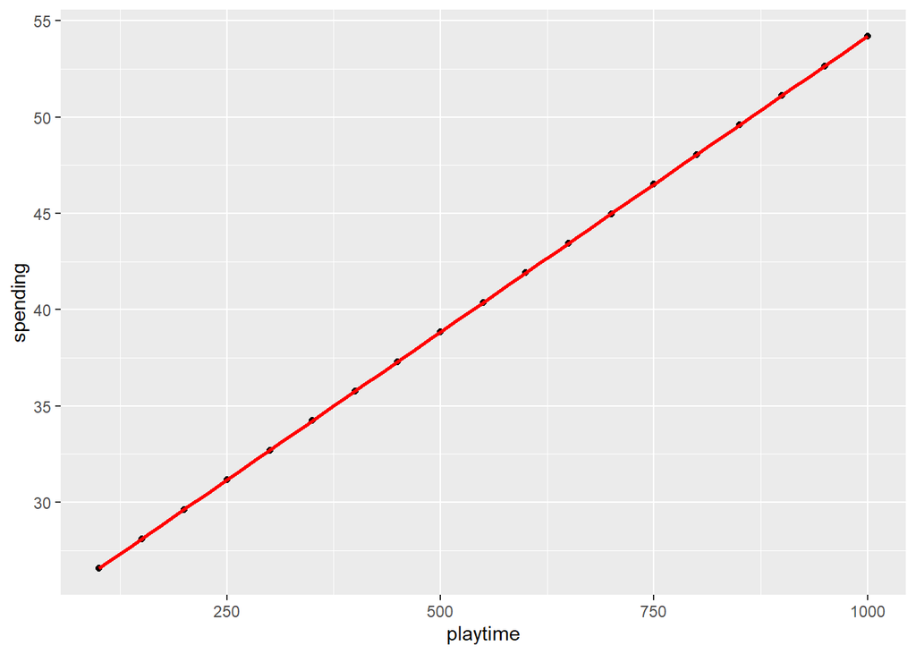

```r
# Create the plot
ggplot(simulation, aes(x = playtime, y = spending))+
  geom_point() +
  geom_smooth(method = "lm", se = FALSE, color = "red")
```

## 4.3 Regression model with numerical and categorical variables

In this step, we fit a multiple linear regression model that includes both numerical and categorical predictors. This allows us to evaluate how each variable contributes to explaining spending while controlling for the others.

```r
model_categorical <- lm(spending ~., DS)
summary(model_categorical)
```

```
##
## Call:
## lm(formula = spending ~ ., data = DS)
##
## Residuals:
##    Min     1Q Median     3Q    Max
## -27.84 -11.95 -10.86  18.79  63.27
##
## Coefficients: (1 not defined because of singularities)
##                    Estimate Std. Error t value Pr(>|t|)
## (Intercept)      12.1609606  8.6151889   1.412    0.158
## player_id        -0.0008686  0.0011759  -0.739    0.460
## groupB           -0.9145783  1.1809808  -0.774    0.439
## playtime         -0.0272042  0.1383370  -0.197    0.844
## sessions         -0.5686428  0.9107584  -0.624    0.532
## levels            0.1937104  0.2703669   0.716    0.474
## friends           0.1138345  0.2309272   0.493    0.622
## skill_score       0.0378145  0.0292811   1.291    0.197
## user_typePremium 14.4470050  2.7209915   5.309 1.27e-07 ***
## engagement_index  0.0055670  0.0146962   0.379    0.705
## engagement               NA         NA      NA       NA
## ---
## Signif. codes:  0 '***' 0.001 '**' 0.01 '*' 0.05 '.' 0.1 ' ' 1
##
## Residual standard error: 19.69 on 1490 degrees of freedom
## Multiple R-squared:  0.02196,    Adjusted R-squared:  0.01605
## F-statistic: 3.717 on 9 and 1490 DF,  p-value: 0.0001253
```

The model has very low explanatory power (R² = 0.02), so it is not accurate. The variable user_typePremium is the only significant predictor: Premium users spend, on average, about 14.45 units more than Freemium users. The group variable (GroupB) is not statistically significant, so we cannot conclude that Group B spends more or less than Group A.

# 5 Classification analysis

In this section, we aim to classify each player as either Premium or Freemium based on their gameplay and engagement metrics. To do so, we apply two supervised learning techniques: a Decision Tree and a k-Nearest Neighbors (K-NN) classifier. We begin by splitting the dataset into training (70%) and testing (30%) sets. Then, we train and evaluate both models using identical splits to ensure a fair comparison. Performance is assessed through accuracy and confusion matrices.

## 5.1 Data splits

We create a partition using user_type as the stratification variable so both sets preserve the original class proportions.

```r
# Split the data into training (70%) and testing (30%)
set.seed(120)

idx_class <- createDataPartition(y = DS$user_type, p = 0.70, list = FALSE)

train_class <- DS[idx_class, ]
test_class  <- DS[-idx_class, ]
```

## 5.2 Build a decision tree

The decision tree uses all available variables to create rules that classify players into Premium or Freemium.

```r
# Train a decision tree using all predictors except user_type
tree_model <- rpart(user_type ~ ., data = train_class)
```

## 5.3 Evaluate the tree

We evaluate the tree by comparing predictions to actual values and computing the overall accuracy and confusion matrix.

```r
# Predict user_type values in the test set
tree_pred <- predict(tree_model, newdata = test_class, type = "class")

# Compute accuracy
tree_accuracy <- mean(tree_pred == test_class$user_type)
tree_accuracy
```

```
## [1] 0.9510022
```

```r
# Compute confusion matrix
tree_conf_matrix <- table(Predicted = tree_pred,
                          Actual = test_class$user_type)
tree_conf_matrix
```

```
##           Actual
## Predicted  Freemium Premium
##   Freemium      427      16
##   Premium         6       0
```

## 5.4 Tree visualisation

The tree plot helps interpret the splitting rules and understand how the model classifies players.

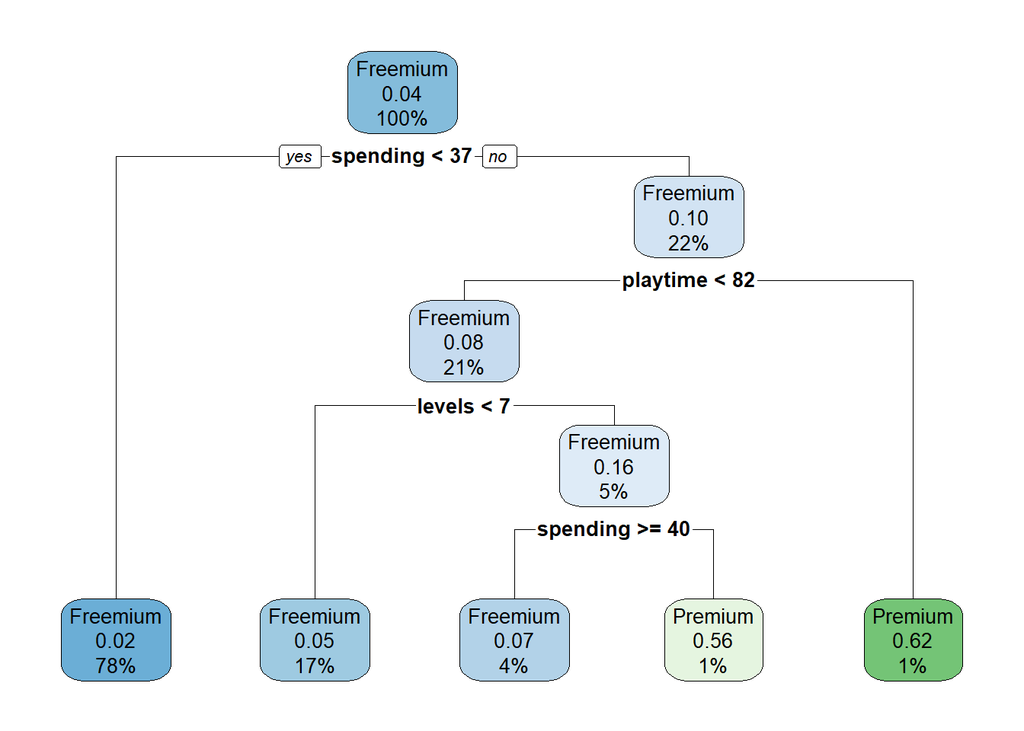

```r
# Visualize the decision tree
rpart.plot(tree_model)
```

## 5.5 Train a K-NN algorithm

K-NN requires numeric predictors, so we restrict the dataset to gameplay metrics. The model automatically applies normalization to ensure all distances are comparable.

```r
# Select only numerical predictors + target (K-NN requires numeric features)
train_knn <- train_class[, c("playtime","sessions","levels","friends","skill_score","user_type")]
test_knn  <- test_class[,  c("playtime","sessions","levels","friends","skill_score","user_type")]

# Train the KNN classifier with centering and scaling
knn_model <- train(user_type ~ .,
                   data = train_knn,
                   method = "knn",
                   preProcess = c("center","scale"))
```

## 5.6 Evaluate the K-NN algorithm

We compute accuracy and the confusion matrix to assess how well the K-NN model distinguishes Premium and Freemium players.

```r
# Predict on the test set
knn_pred <- predict(knn_model, newdata = test_knn)

# Accuracy
knn_accuracy <- mean(knn_pred == test_knn$user_type)
knn_accuracy
```

```
## [1] 0.9643653
```

```r
# Confusion matrix
knn_conf_matrix <- table(Predicted = knn_pred,
                         Actual = test_knn$user_type)
knn_conf_matrix
```

```
##           Actual
## Predicted  Freemium Premium
##   Freemium      433      16
##   Premium         0       0
```

## 5.7 Evaluate and compare

In this final step, we compare the performance and characteristics of the two classification models applied: the Decision Tree and the k-Nearest Neighbors (K-NN) classifier. Both models were trained using the same 70/30 train-test split to ensure consistency in the evaluation.

### 5.7.1 Accuracy comparison

Both models achieved a relatively high overall accuracy. However, this value must be interpreted with caution due to the strong class imbalance in the dataset (96% Freemium, 4% Premium). Since predicting Freemium for all players would already yield high accuracy, this metric alone is not sufficient to assess model quality.

Although both models classify most Freemium users correctly, neither model is able to reliably identify Premium players, which is reflected in the confusion matrices. The class imbalance limits their discriminative power.

### 5.7.2 Confusion matrix interpretation

The Decision Tree tends to predict the majority class (Freemium) for almost all observations. This results in high accuracy for Freemium but very low sensitivity for Premium.

The K-NN model shows a similar pattern: it correctly identifies most Freemium users but struggles to detect Premium users. Since distance-based methods rely on dense regions of the feature space, the scarcity of Premium examples makes it difficult for K-NN to form meaningful neighborhoods for that class.

In both cases, sensitivity toward the Premium class remains extremely low.

### 5.7.3 Interpretability

K-NN: Less interpretable, since predictions depend on distances in the feature space. However, it adapts to local patterns and may perform better than the tree when enough examples exist for each class.

### 5.7.4 Learning behaviour

K-NN: Learns locally, storing all training instances. Still, the imbalance means that most neighbors belong to the Freemium class, so predictions tend toward that class as well.

# 6 Conclusions

## 6.2 Learnings

Throughout the project, several meaningful learnings emerged:

- A/B testing is crucial for decision-making, allowing design hypotheses to be validated with evidence rather than intuition. The A/B that we did in this project is a clear example of how data can guide feature iteration.
- A low R² in regression does not indicate failure, but rather highlights that the model lacks relevant features. More behavioural variables would likely improve the predictive power of the model.
- Accuracy alone is not reliable if there is some class imbalance so additional metrics and rebalancing techniques are necessary.
- Combining descriptive analysis, statistical testing, and machine learning gives a more complete perspective on player behaviour, enabling both strategic insights and actionable recommendations.

# 7 Distribution of tasks

We aimed to organise the workload so that each team member contributed a similar amount of work, and whenever a task was particularly complex, it was handled collaboratively by two people instead of one. The division of tasks was as follows (following the same structure as the table of contents):

1.1. Descriptive metrics – done by Javier Ezquerro.

1.2. Game performance metrics – done by Marc Soriano.